# Nature-based climate resilience through shoreline transformation

Andre de Souza de Lima $^1$; Tyler Miesse $^1$; Daniel Cardona $^1$; Celso Ferreira $^1$; Ali Shahabi $^2$; Navid Tahvildari $^2$

$^1$ Department of Civil, Environmental and Infrastructure Engineering, George Mason University, Fairfax, VA

$^2$ Department of Civil and Environmental Engineering, Old Dominion University, Norfolk, VA

[figure not shown]

## Introduction

Global climate change has led to many adverse impacts including changing weather patterns and an increase in the severity and frequency of extreme weather events. Traditional hard engineering solutions for coastal protection, such as seawalls and bulkheads, are becoming inadequate as they do not have the capacity to keep pace with the accelerating impacts of climate change. In response, there is growing interest in Natural and Nature-Based Features (NNBF), which offer innovative and adaptive approaches to coastal protection. NNBFs, such as salt marshes or living shorelines, have demonstrated potential for mitigating wave energy, reducing flood risks, and enhancing coastal resilience. However, the effectiveness of these features can vary based on their physical attributes and the specific environmental conditions in which they are implemented. The inconsistent performance of NNBFs has posed challenges for their widespread adoption, partly due to uncertainties in their efficacy and barriers in public policy.

This research focuses on evaluating the performance of NNBFs in attenuating waves through innovative field-scale prototypes and the natural environment. Here we aim to deepen our understanding of how these interventions can contribute to enhancing coastal resilience.

```python
import pathlib as pl
import netCDF4 as nc4
import plotly.graph_objs as go
from folium.plugins import BeautifyIcon
import geopandas as gpd
from plotly.subplots import make_subplots
import matplotlib
from scipy.optimize import curve_fit
import folium
import pandas as pd
import numpy as np
```

```python
root = pl.Path('C:/Users/Seagrant_Prj/Data/Marsh')
colors = {'1':'#D81B1B', '2':'#319FFF', '3':'#FFBF00', '4':'#1A8800'}

def datenum_to_datetime(datenum):
    return temp
def make_a_map(id, key, gdf, fg2, strings_dict):
    return fg2
def point_lookup(model_lat:np.array, model_lon:np.array, satellite_lat:np.array, satellite_lon:np.array):
    return distances*6371,indices
def get_location(k, j):
    return L
def get_transect(k, j):
    return t
def updater(fig, xaxis = 'shared'):
    return fig
def func(x, a, b, c):
  return a * np.exp(-b * x) + c
def get_path(i):
    return path
```

## Project Site Location: Severn River Marshland

The Severn River Marshland, situated within the Middle Peninsula Chesapeake Bay Public Access Authority’s (MPCBPAA) Captain Sinclair’s Recreation Area (CSRA) in Gloucester County, Virginia, serves as a living shoreline. This area has been the focus of numerous shoreline protection initiatives designed to mitigate the impacts of erosion, a persistent issue exacerbated by the marsh's exposure to wave energy and storm surges.

[figure not shown]

Notable storm events, such as Hurricane Irene, have underscored the vulnerability and exposure of the site to extreme events.

[figure not shown]

Figure on left shows a numerical model Hurricane Irene's impacts at Mobjack Bay, Virginia; Firgure on the right shows the same numerical model with higher resolution to show the resulting storm surge event at the CRSA. In both figure the pink dot highlights the location of the Severn River Marshland project site

Credits: Flood Hazards Research Lab Archives, 2024

In response to these challenges, various Natural and Nature-Based Features (NNBFs) have been implemented to enhance the resilience of the shoreline. These features include oyster sill bags filled with locally sourced shells from the Chesapeake Bay, rock sills, and naturally occurring salt marshes. Together, these approaches aim to stabilize the shoreline while supporting habitat restoration and wave energy attenuation.

[figure not shown]

Figure on left shows an image of transect 1, highlighting the oyster sill bags and marsh; The center figure shows transect 2; Figure on the right shows transects 3 and 4 highlighting the rock sills and marsh.

Credits: Flood Hazards Research Lab Archives, 2023

Due to the site's exposed condition, we aimed to quanitfy the performance of NNBFs in attenuating waves at the Severn River Marshland. To achieve this, we deployed RBR Solo-D wave loggers along four transects over a year-long monitoring period. Sensors were strategically positioned before and after each type of NNBF within the transects, allowing for detailed analysis of their individual and collective impacts on wave attenuation.

Below is a map of the four transects. Clicking on the sensor points reveals a table with details including the sensor ID, deployment date, location relative to the NNBFs, and data availability.

```python
sensors_marsh
```

[interactive chart not shown]

*Location of RBR solo D Wave Loggers*

### Results

```python
fig.show()
```

[output not shown]

Our results indicate that NNBFs at the Marshland site influence wave attenuation. Moreover, when specific combinations of NNBFs are used, the individual components of the system attenuate waves differently depending on the water levels. To illustrate this, we will analyze a wave event that occurred from November 20 to 23, 2023, focusing specifically on its impacts at Transect 1 to highlight the interaction between the oyster sill bags and the salt marsh.

The top plot presents Hs for three locations: open water (blue), after the oyster sill bags (orange), and after the natural marsh (green). The bottom plot displays water depth at the same locations. Key points of interest are the high and low tides on November 21, 2023. On the Hs plot (top), notice that during high tide, the Hs values at the open water and oyster sensors are nearly identical, whereas the marsh sensor shows significantly lower Hs. Conversely, during low tide, the Hs at the oyster sensor is much lower, and the marsh sensor registers no Hs readings.

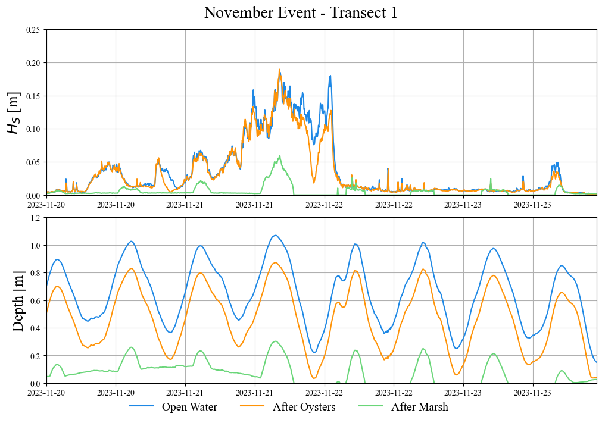

```python
plt.show()
```

To further emphasize patterns seen in the prior time series firgures, we will look the the attenuation coeficient plot below.The figure illustrates the relationship between the attenuation coefficient (𝛼) and water surface elevation (WSE, referenced to NAVD88) at three locations: after the oyster sill bags (orange), at the nearshore marsh (red), and after the natural marsh (green). The attenuation coefficient (𝛼) quantifies the change in inverse wave height over distance:

$$\alpha = \frac{\frac{1}{H_{i}} - \frac{1}{H_0}}{x_i - x_0}$$

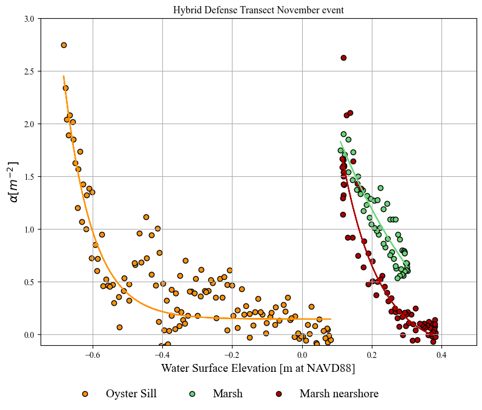

```python
plt.show()
```

### Conclusion

The Severn River Marshland provides a valuable case study for evaluating the effectiveness of Natural and Nature-Based Features (NNBFs) in mitigating wave energy and enhancing shoreline resilience. Our findings demonstrate that NNBFs, such as oyster sill bags and salt marshes, play complementary roles in wave attenuation, with their effectiveness varying depending on water levels. At lower water levels, oyster sill bags serve as a primary attenuator, while at higher water levels, the marsh takes over this function, effectively reducing wave energy. These results highlight the importance of implementing diverse NNBF systems to address the dynamic nature of coastal conditions. By quantifying the performance of these features, this study offers valuable insights into designing and optimizing shoreline protection strategies that promote climate resiliency.